# Intro to classification - Logistic regression - 1

One should look for what is and not what he thinks should be. (Albert Einstein)

# Logistic regression: Topic introduction

In this part of the course, we will cover the following concepts:

- Logistic regression use cases and theory behind it
- Data transformation necessary for logistic regression
- Implementation of logistic regression on a dataset
- Model performance evaluation and tuning

# Quick Activity

- Suppose we want to predict whether a patient will return to our facility
  - What numerical data might be relevant for making this prediction?
  - What additional qualitative or categorical data might be relevant?
  - How might you handle variables like marital status, education level, or gender?

# Module completion checklist

| Objectives | Complete |
| --- | --- |
| Determine when to use logistic regression for classification and transformation of target variable |  |
| Summarize the process and the math behind logistic regression |  |

# Logistic regression

- Logistic regression is a **supervised** machine learning method used for classification
- The **target** or **dependent** variable is binary
  - Yes or no
  - This or that
  - 1 or 0
- The outputs are numerical **probabilities** that different observations will be in the desired class (`y = 1`), rather than category labels

# What logistic regression looks like

- The “logistic” in logistic regression comes from the `logit` function (*a.k.a. sigmoid function*)
- The model solves for coefficients to create a curve maximizing the likelihood of correct classification

# What logistic regression looks like (cont’d)

- The model’s performance can be changed by adjusting the cut-off probability where the curve bends, with no need to re-run the model with new parameters
- Note that we convert the target variable to binary values or either 0 or 1 depending on this cut-off or **threshold**

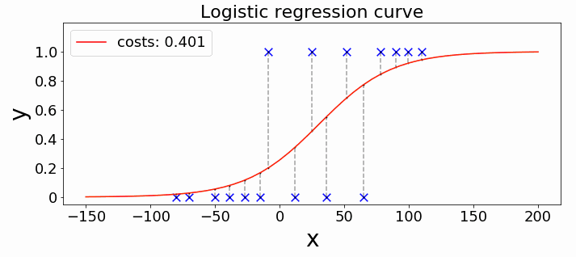

[Source](https://towardsdatascience.com/animations-of-logistic-regression-with-python-31f8c9cb420)

# Logistic regression: process

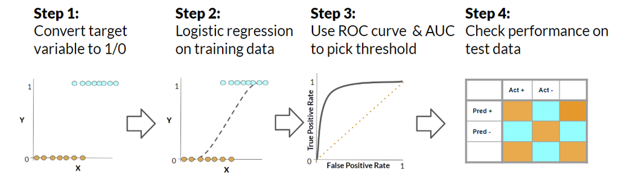

# Converting categorical to binary variable

- There are two main ways to prepare the target variable:
  - First method: translate an existing binary variable (i.e., any categorical variable with 2 classes) into `1` and `0`

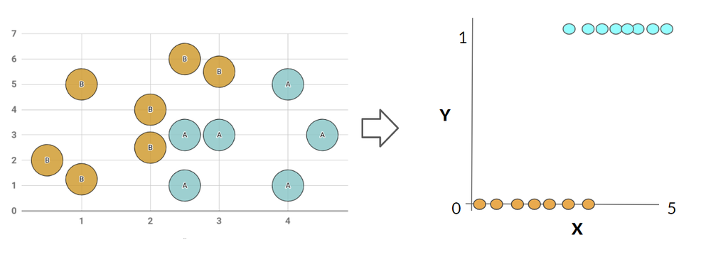

# Converting continuous to binary variable

- Second method: convert a continuous numeric variable into a binary one
  - We can do this by using a **threshold** and labeling observations that are higher than that threshold as `1` and `0` otherwise
  - If the median for the example below was `100`, then any point below the median is coded as `0`, and any point above is `1`

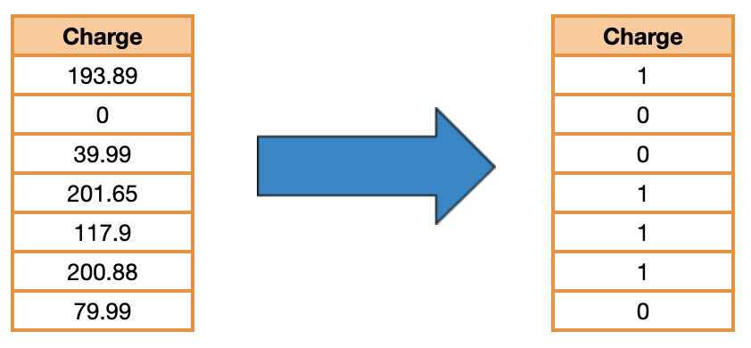

# Module completion checklist

| Objectives | Complete |
| --- | --- |
| Determine when to use logistic regression for classification and transformation of target variable | **✔** |
| Summarize the process and the math behind logistic regression |  |

# Linear vs. logistic regression

Linear regression line

- For data points $x_1, ... , x_n$, we have $y = 0$ or $y = 1$
- The function that “fits” the points is a simple line $\hat{y} = ax + b$

Logistic regression curve

- For the same data points $x_1, ... , x_n$, $y = 0$ or $y = 1$
- The function that “fits” the data points is a sigmoid $p(y = 1) = \frac{exp(ax + b)}{1 + exp(ax + b)}$

# Logistic regression: function

- For every value of $x$, we find $p$ (i.e., probability of success) or probability that $y = 1$
- To solve for $p$, logistic regression uses an expression called a sigmoid function:

$$p = \frac{exp(ax + b)}{1 + exp(ax + b)}$$

- Although it may look a little scary, we can see a very familiar equation inside of the parentheses: $ax + b$
- This is virtually identical to $y = mx + b$

# Logistic regression: the odds ratio

- Through some algebraic transformations that are beyond the scope of this course, we can change this equation

$$p = \frac{exp(ax + b)}{1 + exp(ax + b)}$$

- into a logarithmic expression

$$logit(p) = log \big(\frac{p}{1-p}\big)$$

- Since `p` is the **probability of success**, `1 - p` is the **probability of failure**
- The ratio $\big(\frac{p}{1-p}\big)$ is called the odds ratio - it tells us the odds of having a successful outcome with respect to the opposite
- Knowing this provides useful insight into interpreting the resulting **coefficients**

# Logistic regression: coefficients

- In **linear** regression, the coefficients in the equation can easily be interpreted

$ax + b$

- An increase in $x$ will result in an increase in $y$ and vice versa
- However, in logistic regression, the simplest way to interpret a positive coefficient is with an increase in likelihood
- A larger value of $x$ increases the likelihood that $y = 1$

# Knowledge check

# Module completion checklist

| Objectives | Complete |
| --- | --- |
| Determine when to use logistic regression for classification and transformation of target variable | **✔** |
| Summarize the process and the math behind logistic regression | **✔** |

# Congratulations on completing this module!